# Using Jupyter to Teach and Assess Econometrics

Marina Adshade

Vancouver School of Economics UBC

Jonathan Graves

jonathan.graves@ubc.ca

Vancouver School of Economics UBC

Emrul Hasan

Vancouver School of Economics UBC

2024-06-19

## Pitch: A Common Situation

Have you ever:

- Wanted to show students some cool patterns in data?
- Needed to teach students how to do basic coding?
- Tried to demonstrate a new econometric technique or something?

This is a *major* learning context in any course which deals with or teaches data and computation.

## Problem

However, this is way harder to do than it should be:

- Your students need computers that can run the material…
- They need to have the right software…
- They need to know how to use it: maybe code in it?
- You need to share the learning materials with them.

These are all major points of failure.

## Introduction

In this talk, I will discuss our work developing interactive Jupyter notebooks to help students learn applied econometrics.

[figure not shown]

Our open-source project: COMET [comet.arts.ubc.ca](https://comet.arts.ubc.ca/)

## Outline

1. What are Jupyter Notebooks?
   - What are some alternatives?
   - What are the advantages?
2. How can I use them to teach econometrics?
   - What is our project?
   - What are some strategies for using them?
3. How can I use them for assessment?

## What is a Notebook?

A *notebook* is a digital document which combines rich text (including hyperlinks, formatting, and images) with cells that can perform computations. Examples include:

- Jupyter Notebooks
- RMarkdown Notebooks
- Observable or D3.js

**Key Feature**: a user is able to interact with the content of a notebook, such as performing a computation or changing the text.

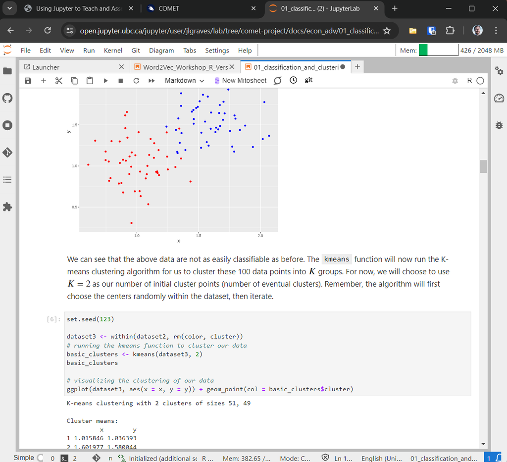

An example of a Jupyter notebook

## Why Notebooks?

Notebooks teach economics students three important skills:

1. **Literate programming**. Popular framework for data analysis (Knuth (1984)), and creates self-documenting tools that address common problems novice (and experienced) researchers face when analyzing data (Kery et al. (2018)).
2. **Replicable** and **reproducible** data analysis (Camerer et al. (2018)). Notebooks encourage replicable programming practices by design, and transparency with experimentation.
3. **Industry-relevant**. Notebooks are extensively used by employers who conduct data science research, or who use data science in their work.

Creating notebooks for classroom instruction turns them from a research tool into a pedagogical tool.

## What is Jupyter?

[Project Jupyter](https://jupyter.org/) is on open-source project to support interactive data science and scientific computing.

- Users connect to a central server, called a [JupyterHub](https://jupyter.org/hub), which runs *kernels* that perform computations.
  - Or: users can run the server locally on their own PC.
- Users interact with the notebooks by editing or running **cells** which contain different kinds of content.

[figure not shown]

Interactive areas in a Jupyter notebooks

## Why Jupyter?

Jupyter has some advantages for teaching not shared by alternatives:

1. **No installation necessary** when used through a [JupyterHub](https://jupyter.org/hub), Jupyter notebooks do not require install any software or a powerful computer.
2. **Simple Github integration**: through [`nbgitpuller`](https://nbgitpuller.readthedocs.io/en/latest/) starting a class is as easy as sharing a link.
3. **Language independence**: computational kernels available for all major languages (R, STATA, Python, Julia, etc.)

## Public or Free Hubs

Where do you find a hub? You have options:

- [Google Colab](https://colab.research.google.com/): [colab.research.google.com](https://colab.research.google.com/)
- [GitHub Codespaces](https://github.com/features/codespaces)
- [Syzygy](https://syzygy.ca/): [syzygy.ca](https://syzygy.ca/)

You can also [set up your own](https://jupyterhub.readthedocs.io/en/stable/tutorial/quickstart.html), or work with non-profits like [2i2c](https://2i2c.org/) to develop your own hub.

## What are the Alternatives?

Jupyter Notebooks are not the only option for teaching using notebooks and there can be advantages to other notebook formats:

- Quarto Notebooks ([quarto.org](https://quarto.org/)): offline or multi-format
- RMarkdown ([rmarkdown.rstudio.com](https://rmarkdown.rstudio.com/)): R programming
- Observable ([observablehq.com](https://observablehq.com/)): dashboards

**Note**: these formats can be converted back and forth.

## How to Use for Teaching?

We have tried several ways of teaching using Jupyter Notebooks, and found that they fit most teaching styles. We have found them particularly effective in:

- Lecture.
- Flipped classrooms.
- Workshops or labs.

However, the *way* you use them and the design of the notebooks differ.

## Lecture and Demonstrations

Jupyter notebooks are most effective in lecture when you use them as a demonstration tool which students can follow along:

- The power of a Jupyter notebook is the interactive nature of the different cells.
- This allows you to enhance your lecture by running cells and changing their values to demonstrate principles.

**Example**

- Try demonstrating a cell, then asking students to predict what happen when you make a different change. Then do it!
- This works great with classroom response systems such as iClicker or TopHat.

## Workshops, Labs, and Flipped Classrooms

“Flipping” (Akçayır and Akçayır (2018)) the lecture demonstration, as discussed, using Jupyter Notebooks is a natural fit.

- The interactivity of notebooks makes them ideal for setting as a “pre-reading” assignment.
- You can also embed interactive “self-tests” into the notebook, to check student understanding (and completion)
- In class, you can then do a more complex example or application.

This also works well for small workshops, TA-led labs, or self-study.

## Assessment

Jupyter Notebooks also make effective assessments:

- Self-tests, combined with hash functions, make good assignments or exams.
- We have used a custom JupyterHub with a Lockdown Browser to carry out computational exams in a “bring your own device” set-up.
  - Can be set-up to distribute and collect exams.
  - Works well with Chromebook-based computer labs.

There are also Jupyter-based assessment systems such as `nbgrader` or `ottergrader`.

## Further Reading

- All of our teaching and learning materials are **free** and **open-source**.
- You can find a copy of this presentation and all the links on our website.
- If you want to get involved or collaborate send me an email: jonathan.graves@ubc.ca

**https://comet.arts.ubc.ca/dissemination**

Thank you!

## References

Akçayır, Gökçe, and Murat Akçayır. 2018. “The Flipped Classroom: A Review of Its Advantages and Challenges.” *Computers & Education* 126: 334–45.

Camerer, Colin F, Anna Dreber, Felix Holzmeister, Teck-Hua Ho, Jürgen Huber, Magnus Johannesson, Michael Kirchler, et al. 2018. “Evaluating the Replicability of Social Science Experiments in Nature and Science Between 2010 and 2015.” *Nature Human Behaviour* 2 (9): 637–44.

Kery, Mary Beth, Marissa Radensky, Mahima Arya, Bonnie E John, and Brad A Myers. 2018. “The Story in the Notebook: Exploratory Data Science Using a Literate Programming Tool.” In *Proceedings of the 2018 CHI Conference on Human Factors in Computing Systems*, 1–11.

Knuth, Donald Ervin. 1984. “Literate Programming.” *The Computer Journal* 27 (2): 97–111.

[figure not shown]